# Data 605 Discussion - Week 7

William Jasmine

2023-03-08

Question comes from [“Introduction to Probability”](https://math.dartmouth.edu/~prob/prob/prob.pdf) by Charles M. Grinstead.

# Question 4, Section 7.2

## Problem Description:

Let $X$, $Y$, and $Z$ be independent random variables with:

$$\begin{equation}
f_X(x) = f_Y(x) = f_Z(x) =
\begin{cases}
1 & \text{if } 0 < x < 1\\
0 & \text{otherwise }
\end{cases}
\end{equation}$$

Suppose that $W = X + Y + Z$. Find $f_W$ directly, and compare your answer with that given by the formula in Example 7.9. Hint: See Example 7.3.

## Solution

From example 7.3 we know that if we say $U = X + Y$ then:

$$\begin{equation}
f_U(u) =
\begin{cases}
u & \text{if } 0 \leq u \leq 1\\
2-u & \text{if } 1 \leq u \leq 2 \\
0 & \text{otherwise}
\end{cases}
\end{equation}$$

Using this substitution, and a process similar to the one carried out in example 7.2, we can now say that:

$$\begin{align}
f_W(w) &= \int_{-\infty}^{\infty}f_X(w-z-y)f_Y(y) dy \\
f_W(w) &= \int_{-\infty}^{\infty}f_Z(w-u)f_U(u) du
\end{align}$$

If $w - u > 0 \Rightarrow u < w$ or $w - u < 1 \Rightarrow u > w-1$, then $f_Z(w-u)=1$, which means that on those bounds:

$$\begin{align}
f_W(w) &= \int_{w-1}^{w}(1)f_U(u) du \\
f_W(w) &= \int_{w-1}^{w}f_U(u) du
\end{align}$$

We can now break up our scenario into three cases. Given that the maximum value of $W$ is three, we check the scenario in which $0 \leq w \leq 1$, $1 \leq w \leq 2$, and $2 \leq w \leq 3$.

### Case 1: $0 \leq w \leq 1$

If $0 \leq w \leq 1$, then we know that $w - 1$ must be less than 0 (and $w < 1$). We can then break apart our previous integral into two pieces, representing the part below 0 and the part above:

$$\begin{align}
f_W(w) &= \int_{w-1}^{w}f_U(u) du \\
f_W(w) &= \int_{w-1}^{0}f_U(u) du + \int_{0}^{w}f_U(u) du
\end{align}$$

$$\begin{align}
f_W(w) &= 0 + \int_{0}^{w}u du \\
f_W(w) &= \frac{w^2}{2}
\end{align}$$

### Case 1: $1 \leq w \leq 2$

Similarly, if If $0 \leq w \leq 1$, then we know that $w - 1$ must be less than 1. Following the same pattern we have:

$$\begin{align}
f_W(w) &= \int_{w-1}^{w}f_U(u) du \\
f_W(w) &= \int_{w-1}^{1}f_U(u) du + \int_{1}^{w}f_U(u) du
\end{align}$$

$$\begin{align}
f_W(w) &= \int_{w-1}^1udu + \int_{1}^{w}(2-u) du \\
f_W(w) &= \frac{u^2}{2}|_{w-1}^1 + 2u-\frac{u^2}{2}|_1^w \\
f_W(w) &= -w^2 + 3w - \frac{3}{2}
\end{align}$$

### Case 1: $2 \leq w \leq 3$

We follow the same steps for this final case:

$$\begin{align}
f_W(w) &= \int_{w-1}^{w}f_U(u) du \\
f_W(w) &= \int_{w-1}^{2}f_U(u) du + \int_{2}^{w}f_U(u) du \\
f_W(w) &= \int_{w-1}^2 (2- u)du + 0 \\
f_W(w) &= 2u - \frac{u^2}{2}|_{w-1}^2 \\
f_W(w) &= \frac{(w-3)^2}{2}
\end{align}$$

### Putting it all together

Based on the previous three subsections, we have that the final equation for $f_W(w)$ is:

$$\begin{equation}
f_W(w) =
\begin{cases}
\frac{w^2}{2} & \text{if } 0 \leq w < 1\\
-w^2 + 3w - \frac{3}{2} & \text{if } 1 \leq w < 2 \\
\frac{(w-3)^2}{2} & \text{if } 2 \leq w \leq 3 \\
0 & \text{otherwise}
\end{cases}
\end{equation}$$

## Empirical Comparison

```r
library(ggplot2)
```

We can simulate this scenario by repeatedly choosing random values between 0 and 1 for three different variables, and summing them together:

```r
set.seed(1234)

# use 30,003 simulations to match seq values in next cell
sims <- 30003
Ws <- numeric(sims)

for (i in 1:3){
  rvs <- runif(sims)
  Ws <- Ws + rvs
}
```

The cell below creates data using the theoretical solution from above:

```r
range1x <- seq(0, 1, 0.0001)
range1y <- (range1x * range1x) / 2
range2x <- seq(1, 2, 0.0001)
range2y <- -(range2x * range2x) + 3 * range2x - (3/2)
range3x <- seq(2, 3, 0.0001)
range3y <- ((range3x - 3) ** 2) / 2

xs <- c(range1x, range2x, range3x)
ys <- c(range1y, range2y, range3y)
plt_data <- data.frame(xs, ys, Ws)
```

A histogram of the simulated data is plotted against the expected density function in the cell below:

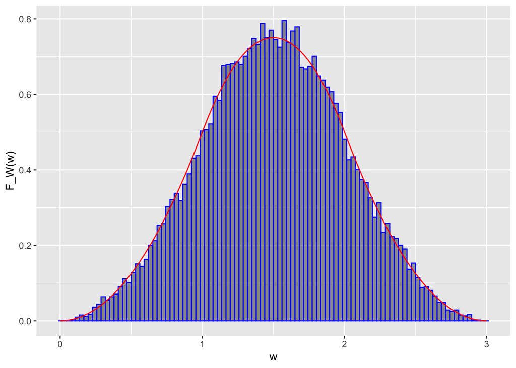

```r
ggplot(data=plt_data) +
  geom_histogram(aes(x=Ws, y=..density..), bins = 100, alpha=0.6, color='blue') +
  geom_line(aes(x=xs, y=ys), color='red') +
  xlab('w') +
  ylab('F_W(w)')
```